# Assignment 1

Gijs Smeets, group 35

February 2023

## Exercise 1

### A

```r
data = read.table('birthweight.txt',header=TRUE)
x = data$birthweight
shapiro.test(x)
```

```
##
##  Shapiro-Wilk normality test
##
## data:  x
## W = 0.99595, p-value = 0.8995
```

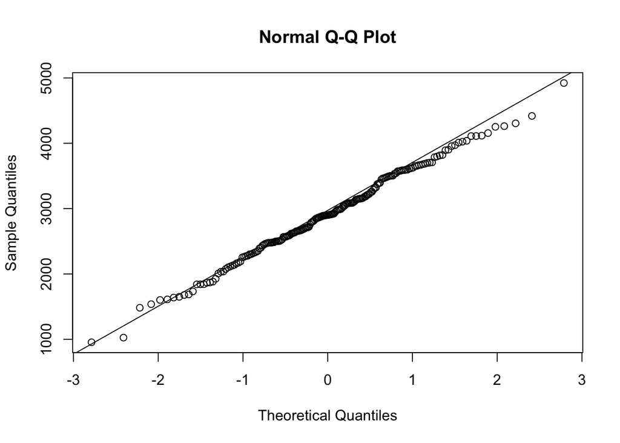

NOW WE CONSTRUCT CI FOR MU, assuming normality

```r
mean = mean(x)
sd = sd(x)
n = length(x)

ci = c((mean - qnorm(0.98)*(sd/sqrt(n))), (mean + qnorm(0.98)*(sd/sqrt(n))))
```

THIS RESULTS IN confidence interval of [2808.817, 3017.768]

Margin of error is 50. Following theory, we have to show that (mathematical: show that `qnorm(0.98)*(sd/sqrt(n)) =< 50)`) n must be larger or equal to `min_n`

```r
min_n = ((qnorm(0.98)^2)*(sd^2))/(50^2)
```

This results in 820.811.

```r
B = 1000
Tstar = numeric(B);
for (i in 1:B){
  Xstar = sample(x,replace=TRUE)
  Tstar[i] = mean(Xstar)
}
Tstar20 = quantile(Tstar,0.020)[[1]]
Tstar980 = quantile(Tstar,0.975)[[1]]
bootstrapci = c(2*mean-Tstar980,2*mean-Tstar20)
```

comparison ci vs bootstrap ci

```r
lenci = ci[2]-ci[1]
lenbsci = bootstrapci[2]-bootstrapci[1]
lenbsci<lenci
```

```
## [1] FALSE
```

### B

```r
t.test(x,mu=2800,alt="g")
```

```
##
##  One Sample t-test
##
## data:  x
## t = 2.2271, df = 187, p-value = 0.01357
## alternative hypothesis: true mean is greater than 2800
## 95 percent confidence interval:
##  2829.202      Inf
## sample estimates:
## mean of x
##  2913.293
```

Proposed sign test: T = #(x>2800)

```r
nT = length(x[x>2800]);
pttest = t.test(x,mu=2800,alt="g")[[3]]
psign = binom.test(nT,n,p=0.5)[[3]]
```

Compare -> should we simulate? or is one enough

```r
pttest<psign
```

```
## [1] TRUE
```

### D

```r
q = length(x[x<2600])/n - 0.25
pr = length(x[x<2600])/n + q
```

```r
ci_p = c(0.25,pr)
```

Confidence interval is [0.25, 0.41]

Now compute confidence level, by (math): q = z_(a/2) * sd/sqrt(n), so z_(a/2) = q * sqrt(n) / sd

```r
z = q * (sqrt(n) / sd)
pnorm(z)
```

```
## [1] 0.5006257
```

Is this correct? -> alpha. Look at this

### E

## Exercise 2

### A

```r
data = read.table('cholesterol.txt',header=TRUE); data
```

|  | Before | After8weeks |
| --- | --- | --- |
| 1 | 6.42 | 5.75 |
| 2 | 6.76 | 6.13 |
| 3 | 6.56 | 5.71 |
| 4 | 4.80 | 4.15 |
| 5 | 8.43 | 7.67 |
| 6 | 7.49 | 7.05 |
| 7 | 8.05 | 7.10 |
| 8 | 5.05 | 4.67 |
| 9 | 5.77 | 5.33 |
| 10 | 3.91 | 3.66 |

[output cut: 8 more lines]

```r
before = data$Before
after = data$After8weeks
summary(data)
```

```
##      Before       After8weeks
##  Min.   :3.910   Min.   :3.660
##  1st Qu.:5.740   1st Qu.:5.210
##  Median :6.500   Median :5.730
##  Mean   :6.408   Mean   :5.779
##  3rd Qu.:7.218   3rd Qu.:6.688
##  Max.   :8.430   Max.   :7.670
```

```r
shapiro.test(before)
```

```
##
##  Shapiro-Wilk normality test
##
## data:  before
## W = 0.9819, p-value = 0.9675
```

```r
shapiro.test(after)
```

```
##
##  Shapiro-Wilk normality test
##
## data:  after
## W = 0.97733, p-value = 0.9183
```

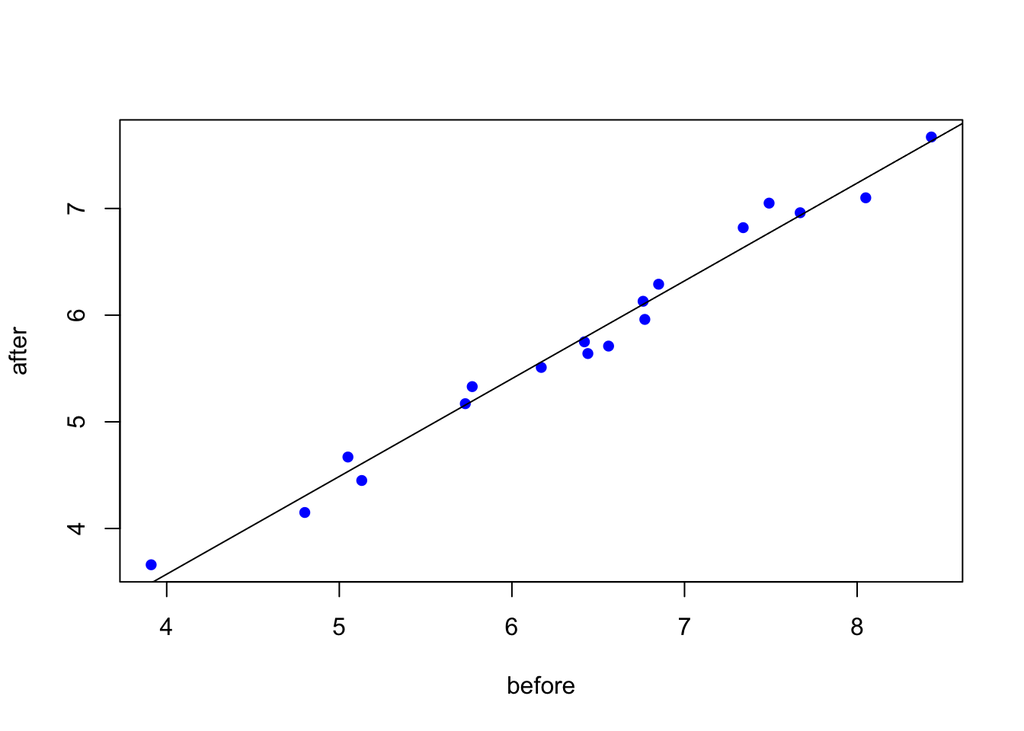

But easier to see, if we remove before bias and only look at first differences:

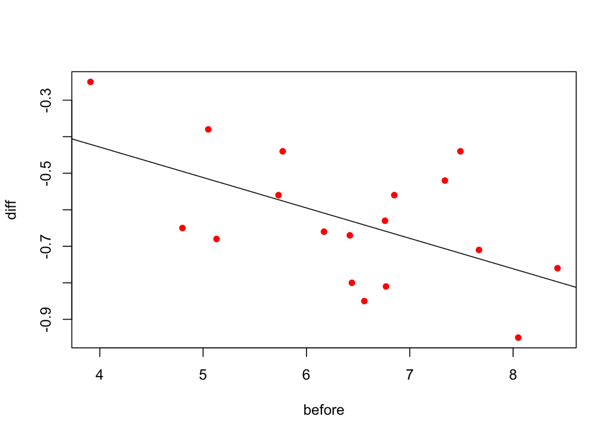

```
##
## Call:
## lm(formula = diff ~ before)
##
## Residuals:
##      Min       1Q   Median       3Q      Max
## -0.20843 -0.15401  0.01823  0.12825  0.27904
##
## Coefficients:
##             Estimate Std. Error t value Pr(>|t|)
## (Intercept) -0.09513    0.20283  -0.469   0.6454
## before      -0.08330    0.03115  -2.674   0.0166 *
## ---
## Signif. codes:  0 '***' 0.001 '**' 0.01 '*' 0.05 '.' 0.1 ' ' 1
##
## Residual standard error: 0.153 on 16 degrees of freedom
## Multiple R-squared:  0.3089, Adjusted R-squared:  0.2657
## F-statistic: 7.151 on 1 and 16 DF,  p-value: 0.01663
```

Notice that decrease in cholesterol level is higher for people who have higher cholesterol level before the experiment

### B

### C

### D

### E

## Exercise 3

### A

### B

### C

### D

### E

## Exercise 4

### A

### B

### C

### D

### E